# Time series & forecasting .

Forecasting the values for TESLA stock listings.

Given : Values till March 07 2017

```python
import pandas as pd
import numpy as np
import random
import seaborn as sns
import matplotlib.pyplot as plt
from numpy import mean, absolute
from statsmodels.tsa.stattools import adfuller
from sklearn.linear_model import LinearRegression
from sklearn.metrics import mean_squared_error
from statsmodels.tsa.holtwinters import ExponentialSmoothing
from statsmodels.tsa.arima_model import ARIMA
```

```python
data = pd.read_csv("/Users/abhishekbidap/Desktop/my_stuff/Quarter 2/Intro to Enterprise/Module 4/TSLA__.csv")
tesla = data.copy()
pd.set_option('display.max_columns', None)
pd.set_option('display.max_rows', None)
```

```python
tesla.head()
```

|  | Date | Open | High | Low | Close | Adj Close | Volume |
| --- | --- | --- | --- | --- | --- | --- | --- |
| 0 | 6/29/10 | 19.000000 | 25.00 | 17.540001 | 23.889999 | 23.889999 | 18766300 |
| 1 | 6/30/10 | 25.790001 | 30.42 | 23.299999 | 23.830000 | 23.830000 | 17187100 |
| 2 | 7/1/10 | 25.000000 | 25.92 | 20.270000 | 21.959999 | 21.959999 | 8218800 |
| 3 | 7/2/10 | 23.000000 | 23.10 | 18.709999 | 19.200001 | 19.200001 | 5139800 |
| 4 | 7/6/10 | 20.000000 | 20.00 | 15.830000 | 16.110001 | 16.110001 | 6866900 |

```python
tesla.isna().sum()
```

```
Date         0
Open         0
High         0
Low          0
Close        0
Adj Close    0
Volume       0
dtype: int64
```

```python
data['Date']= pd.to_datetime(data['Date'])
```

```
------------------------------------------
Test Column: Open
```

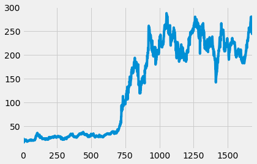

```
------------------------------------------
Test Column: High
```

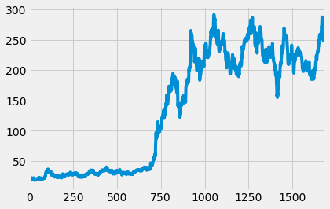

```
------------------------------------------
Test Column: Low
```

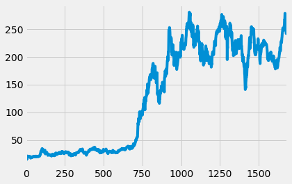

```
------------------------------------------
Test Column: Close
```

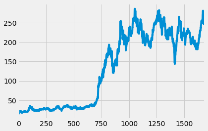

```python
#plotting each column.
for i in data:
    if i not in ['Date','Adj Close','Volume']:
        print("------------------------------------------")
        print('Test Column:',i)
        X=data.loc[:,i]
        X.plot()
        plt.show()
```

```python
def metric_cal(Actual_Values,Predicted_values):
    print("\nMean Absolute Deviation Error (MAD)")
    MAD_Open = mean(absolute(Actual_Values['Open'] - Predicted_values['Open_Predicted']))
    MAD_Close = mean(absolute(Actual_Values['Close'] - Predicted_values['Close_Predicted']))
    MAD_High = mean(absolute(Actual_Values['High'] - Predicted_values['High_Predicted']))
    MAD_Low = mean(absolute(Actual_Values['Low'] - Predicted_values['Low_Predicted']))
    print("Opening Price",MAD_Open,"\nClosing Price",MAD_Close,"\nHighest Price",MAD_High,"\nLowest Price",MAD_Low)

    print("\nMean Square Error (MSE)")
    MSE_Open = mean((Actual_Values['Open'] - Predicted_values['Open_Predicted'])**2)
    MSE_Close = mean((Actual_Values['Close'] - Predicted_values['Close_Predicted'])**2)
    MSE_High = mean((Actual_Values['High'] - Predicted_values['High_Predicted'])**2)
    MSE_Low = mean((Actual_Values['Low'] - Predicted_values['Low_Predicted'])**2)
    print("Opening Price",MSE_Open,"\nClosing Price",MSE_Close,"\nHighest Price",MSE_High,"\nLowest Price",MSE_Low)

    print("\nMean Average Percentage Error (MAPE)")
    MAPE_Open=mean(absolute(Actual_Values['Open'] - Predicted_values['Open_Predicted'])/data['Open']) * 100
    MAPE_Close=mean(absolute(Actual_Values['Close'] - Predicted_values['Close_Predicted'])/data['Close']) * 100
    MAPE_High=mean(absolute(Actual_Values['High'] - Predicted_values['High_Predicted'])/data['High']) * 100
    MAPE_Low=mean(absolute(Actual_Values['Low'] - Predicted_values['Low_Predicted'])/data['Low']) * 100
    print("Opening Price",MAPE_Open,"\nClosing Price",MAPE_Close,"\nHighest Price",MAPE_High,"\nLowest Price",MAPE_Low)
```

```python
def forcast_plot(train,valid):
    plt.style.use("fivethirtyeight")
    for i in train:
        if i in ['Open','Close','High','Low']:
            train.set_index('Date')[i].plot(figsize=(12, 10), linewidth=2.5, color='Black')
            valid.set_index('Date')[i+'_Predicted'].plot(figsize=(12, 10), linewidth=2.5, color='Orange')
            plt.xlabel('Datetime')
            plt.ylabel(i)
            plt.legend(['Training','Validation'])
            plt.show()
```

# Simple Moving Average.

#### Simple Moving Average helps to identify the trends in the data and smoothen the data and emphasizes more on the long term trends.

```python
def my_simple_average(data,k):

    data['Open_Predicted'] = data['Open'].rolling(window=k).mean()
    data['Close_Predicted'] = data['Close'].rolling(window=k).mean()
    data['High_Predicted'] = data['High'].rolling(window=k).mean()
    data['Low_Predicted'] = data['Low'].rolling(window=k).mean()

    #plotting
    train = data[(data.Date < 'Mar 03 2017') & (data.Date >= 'Nov 01 2016')]
    valid = data[(data.Date <= 'Mar 03 2017') & (data.Date >= 'Nov 01 2016')]
    forcast_plot(train,valid)
```

Simple Moving Average with window K=10.

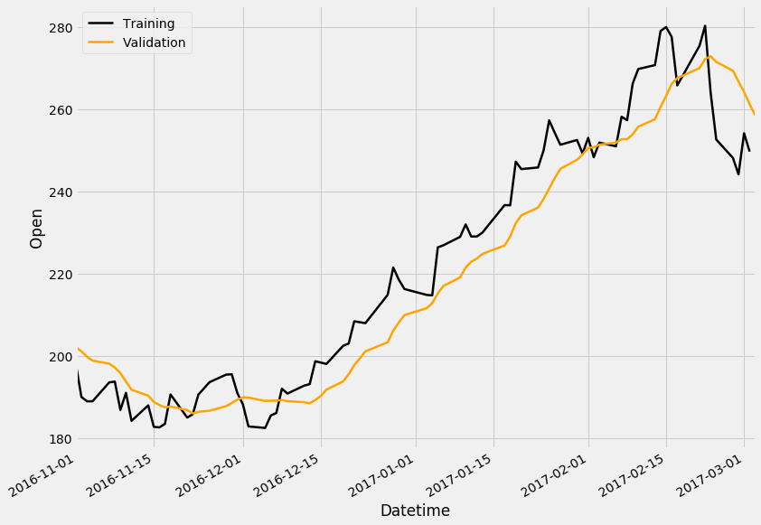

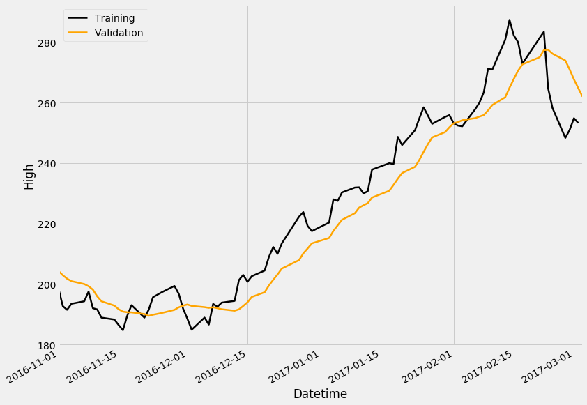

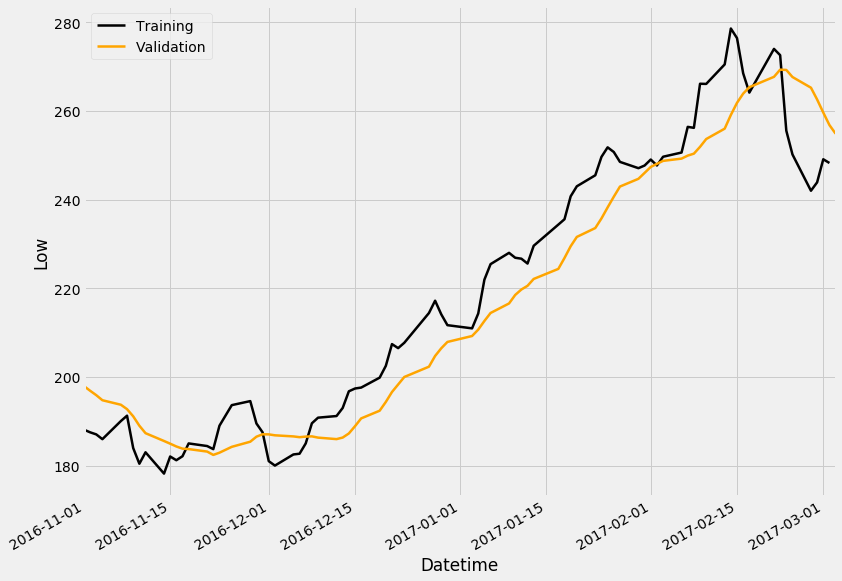

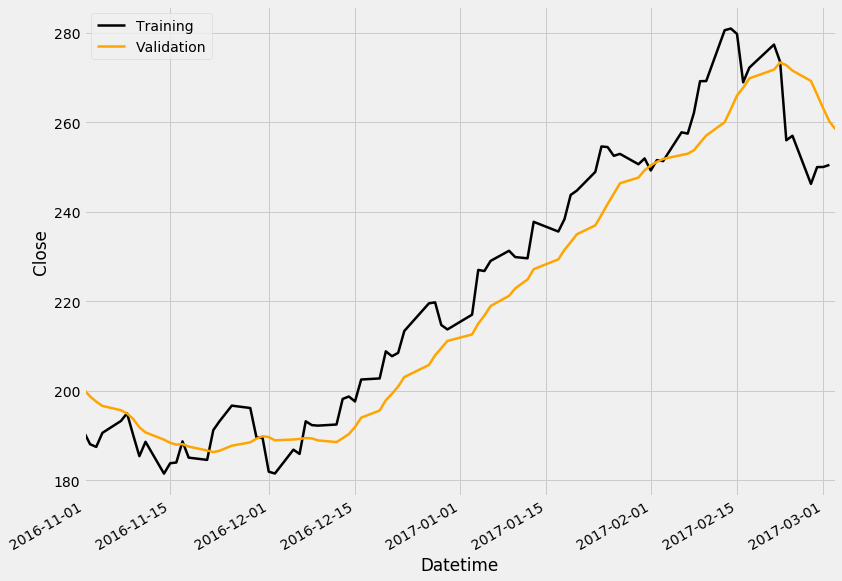

```python
my_simple_average(data,10)
```

#### a.It can be observed that there has been an increasing trend for the last 5 months from the most recent data i.e from 'Nov 01 2016' & 'Mar 03 2017' for all the variables Open,Close,High and Low for TESLA stock listings.

# Weighted Moving Average.

#### With weighted moving average we can emphasize more on the required lags by assigning higher weights.

```python
def my_weighted_average1(data,k,weights):
    if (k != len(weights)):
        print("Error: Value of K is not equal to number of Weights or sum of weights not equals 1")
    else:
        df = pd.DataFrame(data)
        sum_weights = np.sum(weights)

        data['Open_Predicted'] = (data['Open'].rolling(window=k, center=True).apply(lambda x: np.sum(weights*x) / sum_weights, raw=False))

        data['Close_Predicted'] = (data['Close'].rolling(window=k, center=True).apply(lambda x: np.sum(weights*x) / sum_weights, raw=False))

        data['High_Predicted'] = (data['High'].rolling(window=k, center=True).apply(lambda x: np.sum(weights*x) / sum_weights, raw=False))

        data['Low_Predicted'] = (data['Low'].rolling(window=k, center=True).apply(lambda x: np.sum(weights*x) / sum_weights, raw=False))

        #plotting
        train = data[(data.Date < 'Mar 03 2017') & (data.Date >= 'Jan 01 2017')]
        valid = data[(data.Date <= 'Mar 03 2017') & (data.Date >= 'Feb 27 2017')]
        forcast_plot(train,valid)

        #Error metrics
        Actual_Values = data[(data.Date >= 'Feb 27 2017') & (data.Date <= 'Mar 03 2017')]
        Predicted_Values = valid[(data.Date >= 'Feb 27 2017') & (data.Date <= 'Mar 03 2017')]
        metric_cal(Actual_Values,Predicted_Values)
```

Weighted Moving Average with k=2 and weights 0.10,0.90.

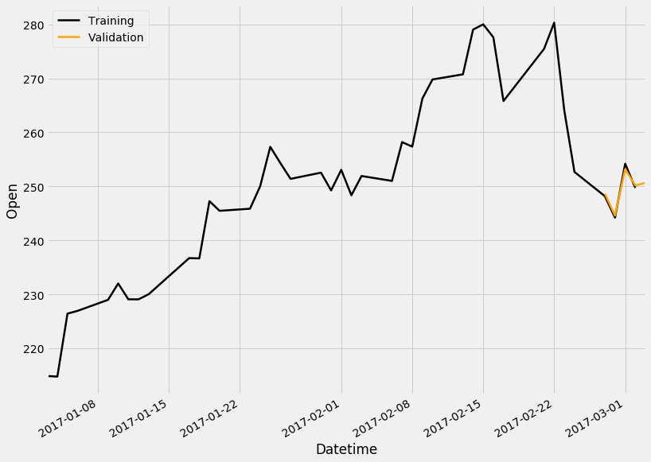

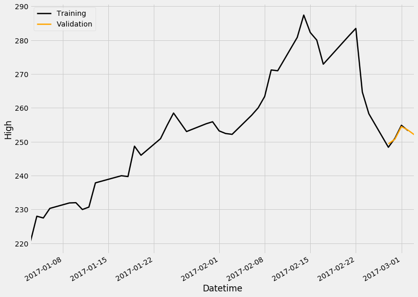

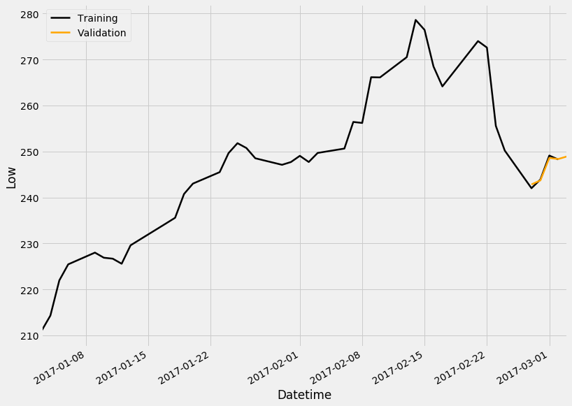

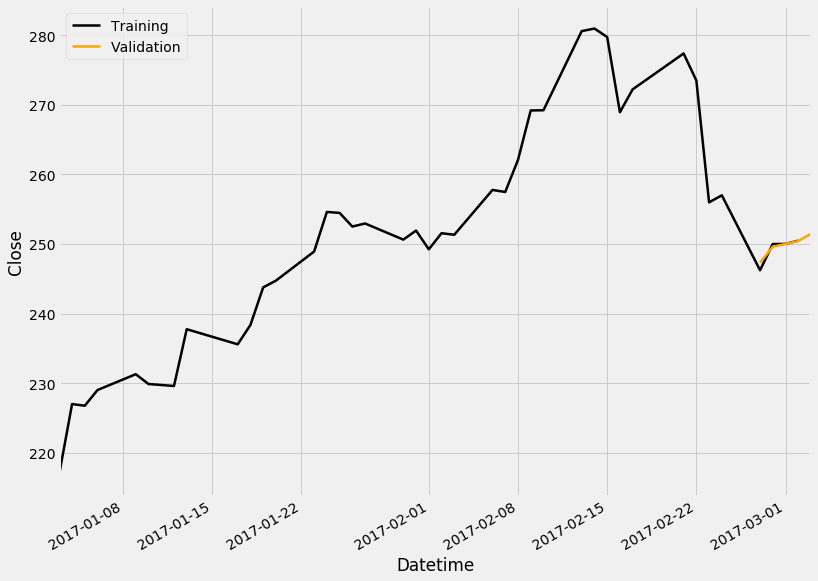

```
Mean Absolute Deviation Error (MAD)
Opening Price 0.4791995399999962
Closing Price 0.3222002999999972
Highest Price 0.3866003199999966
Lowest Price 0.3372000200000002

Mean Square Error (MSE)
Opening Price 0.3136842258806621
Closing Price 0.26306254080056435
Highest Price 0.24794711384021745
Lowest Price 0.19806178208015973

Mean Average Percentage Error (MAPE)
Opening Price 0.19140518230030412
Closing Price 0.13013901897308836
Highest Price 0.15424636334739167
Lowest Price 0.13764050948250642
```

```python
my_weighted_average1(data,2,[0.10,0.90])
```

Weighted Moving Average with k=3 and weights 0.10 0.20,0.70.

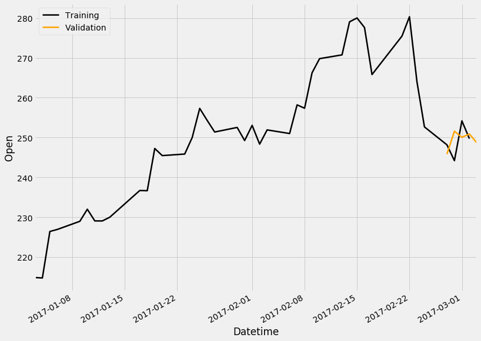

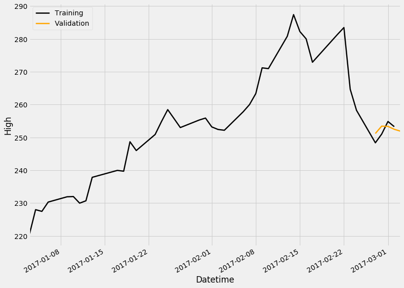

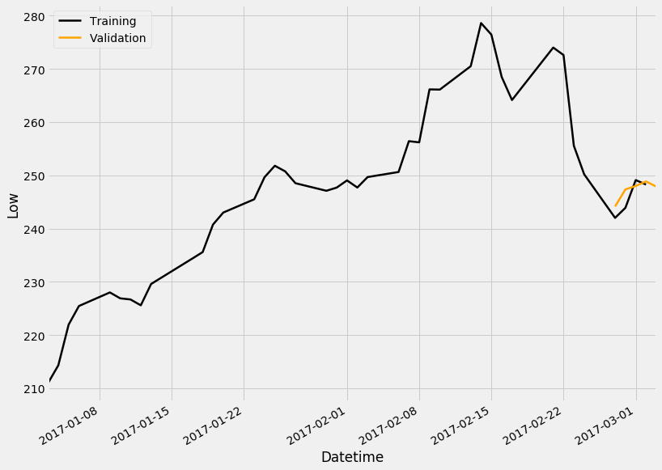

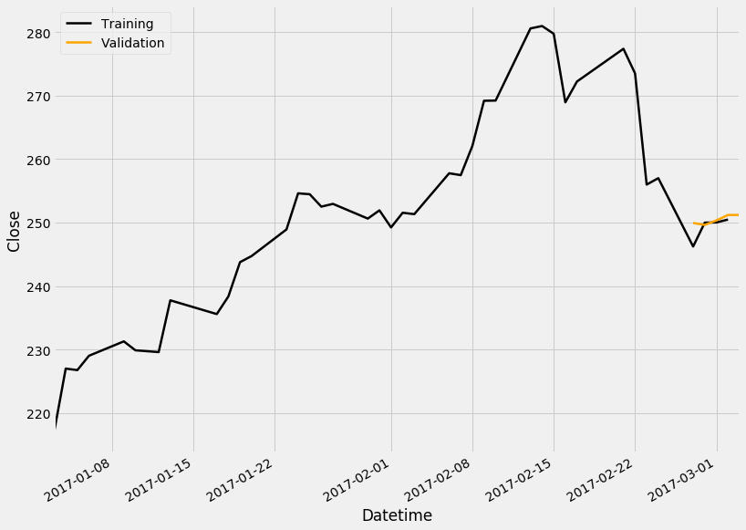

```
Mean Absolute Deviation Error (MAD)
Opening Price 3.421595379999991
Closing Price 1.0922024799999803
Highest Price 1.512601840000002
Lowest Price 1.6840006199999777

Mean Square Error (MSE)
Opening Price 16.567181254635777
Closing Price 2.925787462190145
Highest Price 3.3630216422927965
Lowest Price 3.875064512609213

Mean Average Percentage Error (MAPE)
Opening Price 1.3782707555443663
Closing Price 0.44113298910125115
Highest Price 0.602665915552746
Lowest Price 0.6871837923711224
```

```python
my_weighted_average1(data,3,[0.10,0.20,0.70])
```

#### Error metric : Mean Square Error Metric for the K=2 and Weights 0.10,0.90 are far more better where maximum emphasis is on the recent lag 1 data.

# Checking Stationarity of Data.

```python
#Dicky fuller test to check if the data is stationary or not.
#Null hypothesis : We have a non stationary dataset.
#Alternate Hypothesis :We have a stationary dataset.
#https://machinelearningmastery.com/time-series-data-stationary-python/
from statsmodels.tsa.stattools import adfuller

def dicky_fuller_test(input_col):
    X=input_col
    result = adfuller(X)
    print('ADF Statistic: %f' % result[0])
    print('p-value: %f' % result[1])
    print('Critical Values:')
    for key, value in result[4].items():
        print('\t%s: %.3f' % (key, value))
for i in data:
    if i in ['Open','Close','High','Low']:
        print("------------------------------------------")
        print('Test Column:',i)
        X=data.loc[:,i]
        dicky_fuller_test(X)

#p-value > 0.05: Fail to reject the null hypothesis (H0).
#p-value <= 0.05: Reject the null hypothesis (H0).
```

```
------------------------------------------
Test Column: Open
ADF Statistic: -0.895025
p-value: 0.789606
Critical Values:
	1%: -3.434
	5%: -2.863
	10%: -2.568
------------------------------------------
Test Column: High
ADF Statistic: -0.887391
p-value: 0.792096
Critical Values:
	1%: -3.434
	5%: -2.863
	10%: -2.568
------------------------------------------
Test Column: Low
ADF Statistic: -0.929777
p-value: 0.778008
Critical Values:
	1%: -3.434
	5%: -2.863
	10%: -2.568
------------------------------------------
Test Column: Close
ADF Statistic: -0.897490
p-value: 0.788798
Critical Values:
	1%: -3.434
	5%: -2.863
	10%: -2.568
```

**P-value for all the variables in the data > 0.05: Fail to reject the null hypothesis (H0).i.e We have a non stationary dataset**

```python
#KPSS test to check if the data is stationary or not.
#Null hypothesis : We have a trend stationary dataset.
#Alternate Hypothesis :We have a non stationary dataset.
#https://www.analyticsvidhya.com/blog/2018/09/non-stationary-time-series-python/

#define function for kpss test
from statsmodels.tsa.stattools import kpss
#define KPSS
def kpss_test(timeseries):
    print ('Results of KPSS Test:')
    kpsstest = kpss(timeseries, regression='c')
    kpss_output = pd.Series(kpsstest[0:3], index=['Test Statistic','p-value','Lags Used'])
    for key,value in kpsstest[3].items():
        kpss_output['Critical Value (%s)'%key] = value
    print (kpss_output)
for i in data:
    if i in ['Open','Close','High','Low']:
        print("------------------------------------------")
        print('Test Column:',i)
        X=data.loc[:,i]
        kpss_test(X)

#p-value > 0.05: Fail to reject the null hypothesis (H0).
#p-value <= 0.05: Reject the null hypothesis (H0).
```

```
------------------------------------------
Test Column: Open
Results of KPSS Test:
Test Statistic            5.768672
p-value                   0.010000
Lags Used                25.000000
Critical Value (10%)      0.347000
Critical Value (5%)       0.463000
Critical Value (2.5%)     0.574000
Critical Value (1%)       0.739000
dtype: float64
------------------------------------------
Test Column: High
Results of KPSS Test:
Test Statistic            5.765299
p-value                   0.010000
Lags Used                25.000000
Critical Value (10%)      0.347000
Critical Value (5%)       0.463000
Critical Value (2.5%)     0.574000
Critical Value (1%)       0.739000
dtype: float64
------------------------------------------
Test Column: Low
Results of KPSS Test:
Test Statistic            5.774164
p-value                   0.010000
Lags Used                25.000000
Critical Value (10%)      0.347000
Critical Value (5%)       0.463000
Critical Value (2.5%)     0.574000
Critical Value (1%)       0.739000
dtype: float64
------------------------------------------
Test Column: Close
Results of KPSS Test:
Test Statistic            5.769559
p-value                   0.010000
Lags Used                25.000000
Critical Value (10%)      0.347000
Critical Value (5%)       0.463000
Critical Value (2.5%)     0.574000
Critical Value (1%)       0.739000
dtype: float64
```

**p-value <= 0.05: Reject the null hypothesis (H0).i.e We have a non stationary dataset.**

# Checking the ADF and KPSS after differencing of the columns

```
Column: Open
```

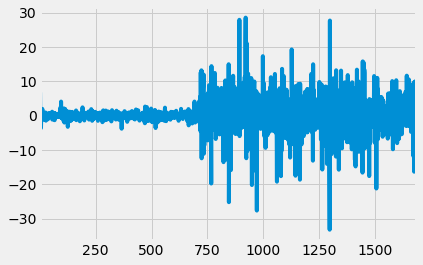

```
Results of ADF Test:
ADF Statistic: -42.687738
p-value: 0.000000
Critical Values:
	1%: -3.434
	5%: -2.863
	10%: -2.568
Results of KPSS Test:
Test Statistic            0.059567
p-value                   0.100000
Lags Used                25.000000
Critical Value (10%)      0.347000
Critical Value (5%)       0.463000
Critical Value (2.5%)     0.574000
Critical Value (1%)       0.739000
dtype: float64
-------------------------------------
Column: High
```

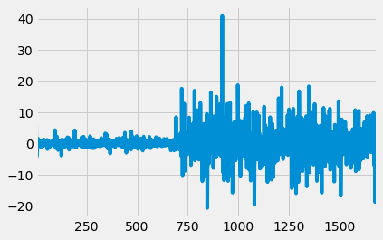

```
Results of ADF Test:
ADF Statistic: -17.168738
p-value: 0.000000
Critical Values:
	1%: -3.434
	5%: -2.863
	10%: -2.568
Results of KPSS Test:
Test Statistic            0.064424
p-value                   0.100000
Lags Used                25.000000
Critical Value (10%)      0.347000
Critical Value (5%)       0.463000
Critical Value (2.5%)     0.574000
Critical Value (1%)       0.739000
dtype: float64
-------------------------------------
Column: Low
```

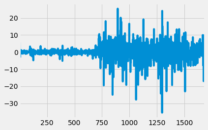

```
Results of ADF Test:
ADF Statistic: -28.950677
p-value: 0.000000
Critical Values:
	1%: -3.434
	5%: -2.863
	10%: -2.568
Results of KPSS Test:
Test Statistic            0.058196
p-value                   0.100000
Lags Used                25.000000
Critical Value (10%)      0.347000
Critical Value (5%)       0.463000
Critical Value (2.5%)     0.574000
Critical Value (1%)       0.739000
dtype: float64
-------------------------------------
Column: Close
```

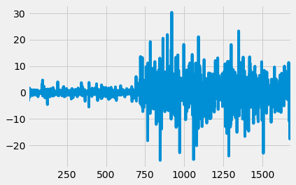

```
Results of ADF Test:
ADF Statistic: -39.728000
p-value: 0.000000
Critical Values:
	1%: -3.434
	5%: -2.863
	10%: -2.568
Results of KPSS Test:
Test Statistic            0.06279
p-value                   0.10000
Lags Used                25.00000
Critical Value (10%)      0.34700
Critical Value (5%)       0.46300
Critical Value (2.5%)     0.57400
Critical Value (1%)       0.73900
dtype: float64
-------------------------------------
```

```python
#checking the ADF and KPSS after differencing of the columns.
for i in data:
    if i in ['Open','Close','High','Low']:
        print("Column:",i)
        x = data[i] - data[i].shift(1)
        Y = x.dropna()
        Y.plot()
        plt.show()
        print("Results of ADF Test:")
        dicky_fuller_test(Y)
        kpss_test(Y)
        print("-------------------------------------")
```

#### It can be seen that after differencing our data is now stationary as required and tested using the ADF and the KPSS tests.

# Durbin-Watson Statistic -

#### Test statistic used to detect the presence of autocorrelation at lag 1 in the residuals from a regression analysis.

```python
from statsmodels.stats.stattools import durbin_watson
print('DW statistic for Opening Price is: ',durbin_watson(tesla['Open']))
print('DW statistic for Closing Price is: ',durbin_watson(tesla['Close']))
print('DW statistic for Highest Price is: ',durbin_watson(tesla['High']))
print('DW statistic for Lowest Price is: ',durbin_watson(tesla['Low']))
```

```
DW statistic for Opening Price is:  0.0008402831823626482
DW statistic for Closing Price is:  0.0007333546150387083
DW statistic for Highest Price is:  0.0005890708602447673
DW statistic for Lowest Price is:  0.0007372830417820543
```

#### Since DW statistic is close to 0, it mean that first order positive autocorrelation exists for opening price, closing price, highest price, lowest price.

# ARIMA MODEL :

1.Check for the ACF AND PACF plots.

Help to detect the autoregreesive terms and moving average terms.

Autoregressive - forecast the next timestamp value by regressing over the previous values.  
Moving average - forecast the nest timestamp value by regressing over the previous values.

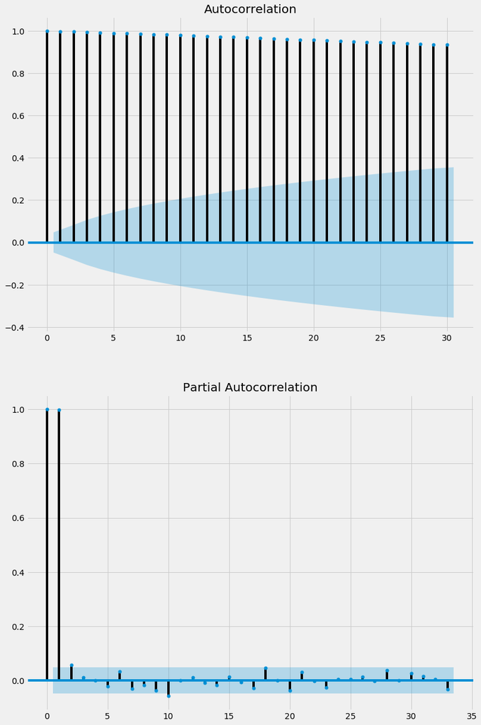

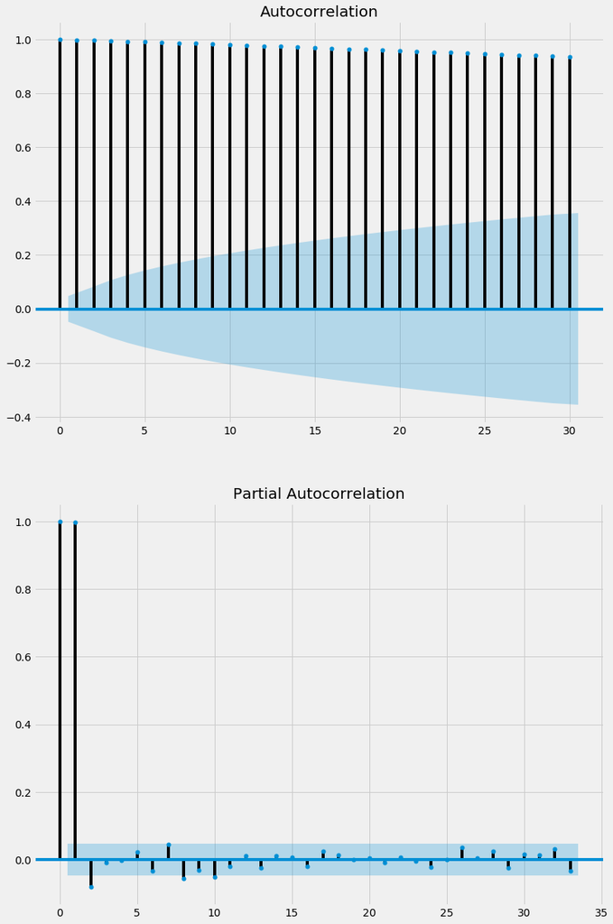

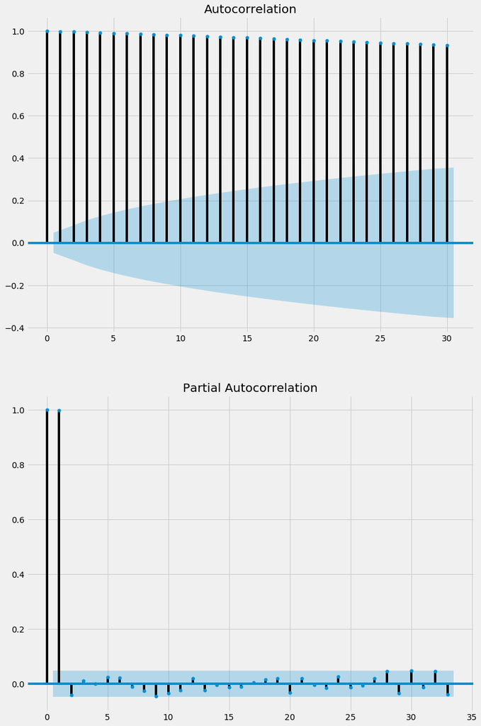

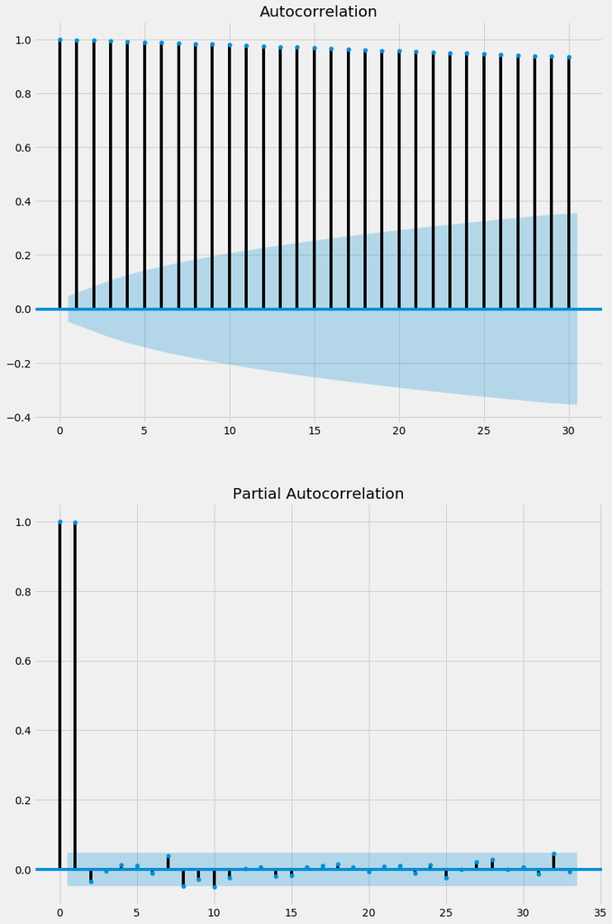

```python
from statsmodels.graphics.tsaplots import plot_acf
from statsmodels.graphics.tsaplots import plot_pacf
from matplotlib import pyplot

for i in data:
    if i in ['Open','Close','High','Low']:
        pyplot.figure()
        plt.figure(figsize=(12,20))
        pyplot.subplot(211)
        plot_acf(data[i], ax=pyplot.gca(),lags=30)
        pyplot.subplot(212)

        plot_pacf(data[i], ax=pyplot.gca())
        pyplot.show()
```

ARIMA(p,d,q)

```python
data.head()
data1 = data.copy()
```

```python
data[(data.Date < 'Mar 03 2017') & (data.Date >= 'Jan 01 2017')].head(5)
```

|  | Date | Open | High | Low | Close | Adj Close | Volume | Open_Predicted | Close_Predicted | High_Predicted | Low_Predicted |
| --- | --- | --- | --- | --- | --- | --- | --- | --- | --- | --- | --- |
| 1640 | 2017-01-03 | 214.860001 | 220.330002 | 210.960007 | 216.990005 | 216.990005 | 5923300 | 214.927000 | 223.660005 | 225.416000 | 213.376999 |
| 1641 | 2017-01-04 | 214.750000 | 228.000000 | 214.309998 | 226.990005 | 226.990005 | 11213500 | 222.929999 | 225.822001 | 226.868997 | 219.322998 |
| 1642 | 2017-01-05 | 226.419998 | 227.479996 | 221.949997 | 226.750000 | 226.750000 | 5911700 | 225.609995 | 228.355997 | 229.512998 | 223.635997 |
| 1643 | 2017-01-06 | 226.929993 | 230.309998 | 225.449997 | 229.009995 | 229.009995 | 5527900 | 228.306999 | 230.372998 | 231.153998 | 226.884999 |
| 1644 | 2017-01-09 | 228.970001 | 231.919998 | 228.000000 | 231.279999 | 231.279999 | 3979500 | 230.886999 | 230.065996 | 231.814999 | 226.967999 |

```python
def ARIMA_model(data):

    ARIMA_model_1 = ARIMA(data['Open'],order=(0,1,0)).fit(transparam=False)
    ARIMA_model_2 = ARIMA(data['High'],order=(1,1,0)).fit(transparam=False)
    ARIMA_model_3 = ARIMA(data['Low'],order=(1,1,0)).fit(transparam=False)
    ARIMA_model_4 = ARIMA(data['Close'],order=(0,1,0)).fit(transparam=False)
    ARIMA_model_5 = ARIMA(data['Volume'],order=(1,1,1)).fit(transparam=False)

    print(ARIMA_model_1.summary())
    print(ARIMA_model_2.summary())
    print(ARIMA_model_3.summary())
    print(ARIMA_model_4.summary())
    print(ARIMA_model_5.summary())

    data['Open'+'_Predicted'] = ARIMA_model_1.predict(typ='levels')
    data['Close'+'_Predicted'] = ARIMA_model_2.predict(typ='levels')
    data['High'+'_Predicted'] = ARIMA_model_3.predict(typ='levels')
    data['Low'+'_Predicted'] = ARIMA_model_4.predict(typ='levels')

    train = data[(data.Date < 'Mar 07 2017') & (data.Date >= 'Jan 01 2017')]
    valid = data[(data.Date <= 'Mar 07 2017') & (data.Date >= 'Mar 03 2017')]
    forcast_plot(train,valid)

    #Error metrics
    Actual_Values = data[(data.Date >= 'Feb 27 2017') & (data.Date <= 'Mar 03 2017')]
    Predicted_Values = valid[(data.Date >= 'Feb 27 2017') & (data.Date <= 'Mar 03 2017')]

    metric_cal(Actual_Values,Predicted_Values)

    #forecasting next week values
    print("----------------------------------------------------------------------")
    print("As the MSE observed with the validation data is comparatively less we be Using the above performed ARIMA model we would be making the predictions for the week Mar 6 to Mar 12 2017.")
    print("Forecasts for the next 7 Business Days Week from 6th March 2017:")

    forecast_1 = ARIMA_model_1.forecast(steps=7,exog=None, alpha=0.05)
    forecast_2 = ARIMA_model_2.forecast(steps=7,exog=None, alpha=0.05)
    forecast_3 = ARIMA_model_3.forecast(steps=7,exog=None, alpha=0.05)
    forecast_4 = ARIMA_model_4.forecast(steps=7,exog=None, alpha=0.05)

    date=['2017-03-06','2017-03-07','2017-03-08','2017-03-09','2017-03-10','2017-03-11','2017-03-12']
    pred=pd.DataFrame({'Date':date,'Open_Predicted':forecast_1[0],'Close_Predicted':forecast_2[0],'High_Predicted':forecast_3[0],'Low_Predicted':forecast_4[0]})

    pred['Date']= pd.to_datetime(pred['Date'])

    def prediction_plot(train,valid):
        plt.style.use("fivethirtyeight")
        for i in train:
            if i in ['Open','Close','High','Low']:
                train.set_index('Date')[i].plot(figsize=(12, 10), linewidth=2.5, color='Black')
                valid.set_index('Date')[i+'_Predicted'].plot(figsize=(12, 10), linewidth=2.5, color='Orange')
                plt.xlabel('Datetime')
                plt.ylabel(i)
                plt.legend(['Training','Forecast'])
                plt.show()

    prediction_plot(train,pred)
```

```
                             ARIMA Model Results
==============================================================================
Dep. Variable:                 D.Open   No. Observations:                 1683
Model:                 ARIMA(0, 1, 0)   Log Likelihood               -4991.269
Method:                           css   S.D. of innovations              4.696
Date:                Sat, 21 Mar 2020   AIC                           9986.538
Time:                        17:21:49   BIC                           9997.394
Sample:                             1   HQIC                          9990.559

==============================================================================
                 coef    std err          z      P>|z|      [0.025      0.975]
------------------------------------------------------------------------------
const          0.1384      0.114      1.209      0.227      -0.086       0.363
==============================================================================
                             ARIMA Model Results
==============================================================================
Dep. Variable:                 D.High   No. Observations:                 1683
Model:                 ARIMA(1, 1, 0)   Log Likelihood               -4704.443
Method:                       css-mle   S.D. of innovations              3.960
Date:                Sat, 21 Mar 2020   AIC                           9414.887
Time:                        17:21:49   BIC                           9431.172
Sample:                             1   HQIC                          9420.919

================================================================================
                   coef    std err          z      P>|z|      [0.025      0.975]
--------------------------------------------------------------------------------
const            0.1367      0.112      1.225      0.221      -0.082       0.355
ar.L1.D.High     0.1350      0.024      5.587      0.000       0.088       0.182
                                    Roots
=============================================================================
                  Real          Imaginary           Modulus         Frequency
-----------------------------------------------------------------------------
AR.1            7.4079           +0.0000j            7.4079            0.0000
-----------------------------------------------------------------------------
                             ARIMA Model Results
==============================================================================
Dep. Variable:                  D.Low   No. Observations:                 1683
Model:                 ARIMA(1, 1, 0)   Log Likelihood               -4846.742
Method:                       css-mle   S.D. of innovations              4.310
Date:                Sat, 21 Mar 2020   AIC                           9699.485
```

[output cut: 35 more lines]

```
Sample:                             1   HQIC                         54451.876

==================================================================================
                     coef    std err          z      P>|z|      [0.025      0.975]
----------------------------------------------------------------------------------
const          -9094.9495   8732.245     -1.042      0.298   -2.62e+04    8019.937
ar.L1.D.Volume     0.5120      0.028     18.580      0.000       0.458       0.566
ma.L1.D.Volume    -0.9390      0.013    -69.834      0.000      -0.965      -0.913
                                    Roots
=============================================================================
                  Real          Imaginary           Modulus         Frequency
-----------------------------------------------------------------------------
AR.1            1.9530           +0.0000j            1.9530            0.0000
MA.1            1.0650           +0.0000j            1.0650            0.0000
-----------------------------------------------------------------------------
```

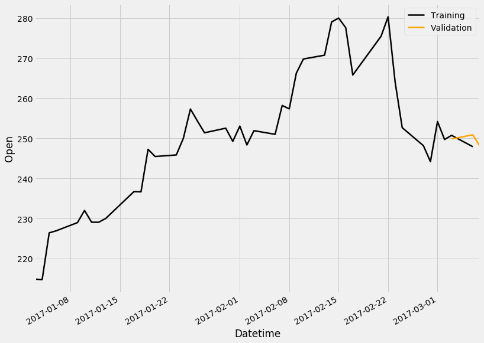

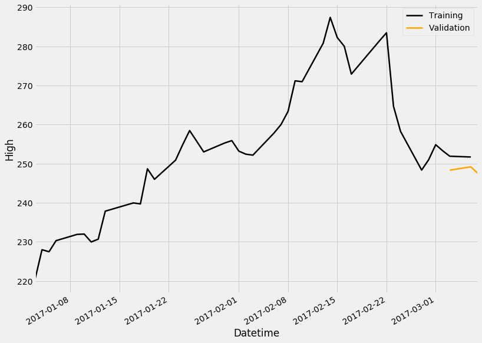

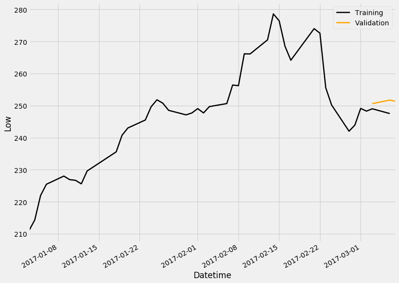

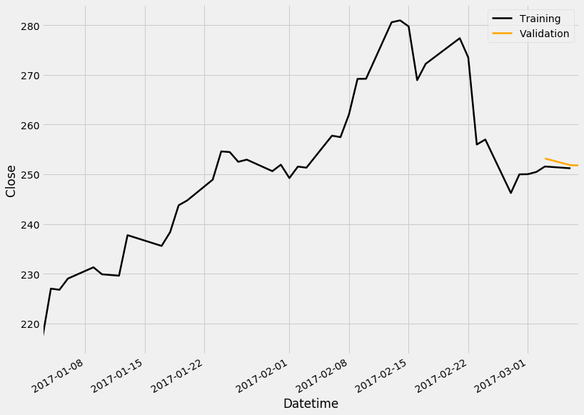

[output not shown]

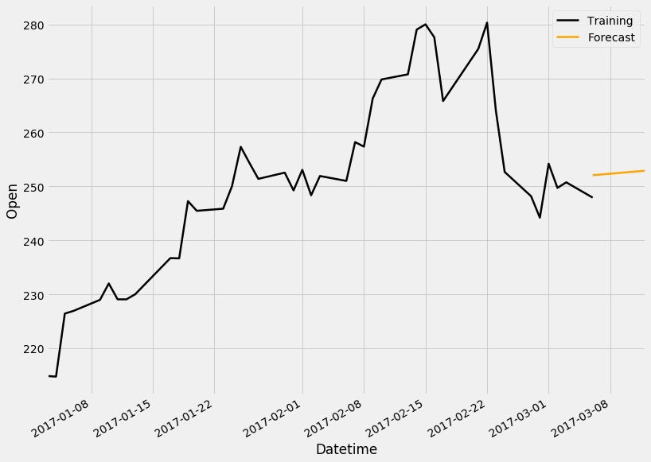

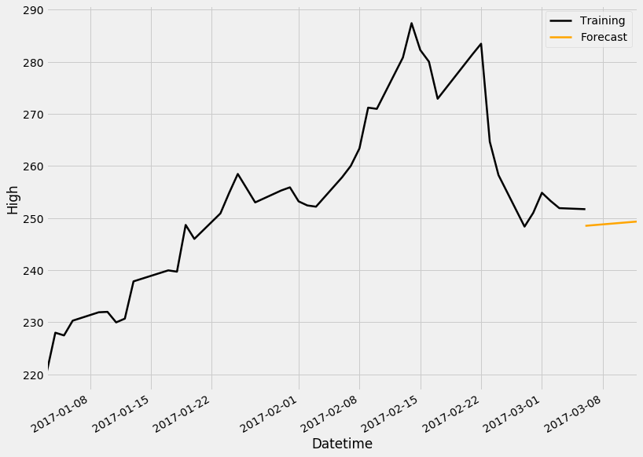

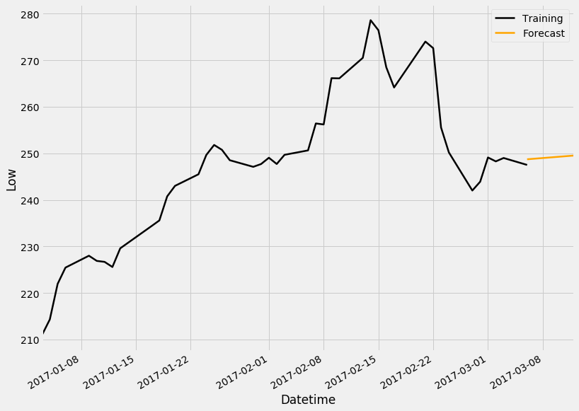

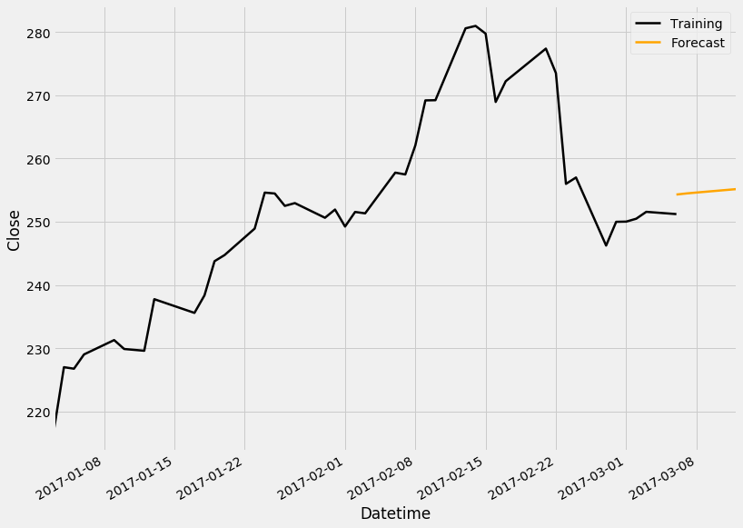

```python
ARIMA_model(data)
```